# Coursework_MAP501_2021

Eugenie Hunsicker

today

# Instructions

In this coursework, we will be using several datasets about baseball from the package ‘Lahman’. You can access the list of datasets and all of the variables contained in each one by examining this package in the Packages tab in RStudio.

Please do not change anything in the Preamble section.

Marks are given for each part of each question in the form [C (points for code)+ D (points for discussion)] . To achieve full points for code, code must use tidyverse syntax where possible.

# Preamble

```r
library("car")
library("tidyverse")
library("magrittr")
library("here")
library("janitor")
library("lubridate")
library("gridExtra")
library("readxl")
library("glmnet")
library("Lahman")
library("viridis")
library("lindia")
library("lme4")
library("caret")
library("pROC")
```

# 1. Datasets

1. [3 + 0 points] Create a new dataset called ‘Peopledata’ that contains all of the variables in the ‘People’ dataset by
2. removing all birth information except birthYear and birthCountry and all death information, along with the variable finalGame;

```r
Peopledata <- People %>%
  select(-c(contains("birth") & !birthYear & !birthCountry)) %>%
  select(c(-contains("death"))) %>%
  select(-c(contains("ID") & !playerID))%>%
  select(c(-nameGiven)) %>%
  select(c(-finalGame))
```

```
ii. replacing birthCountry is by bornUSA, a logical variable indicating if the player was born in the USA;
```

```r
Peopledata <- Peopledata %>%
  mutate(bornUSA = ifelse(Peopledata$"birthCountry"== "USA",TRUE,FALSE))%>%
  select(c(-birthCountry))
```

2. [5 + 0 points] Create new datasets called Battingdata and Fieldingdata by

```
i. choosing data from the years 1985 and 2015,
```

```r
Battingdata <- Batting %>%
  filter(yearID == "1985" | yearID == "2015")

Fieldingdata <- Fielding %>%
    filter(yearID == "1985" | yearID == "2015")
```

```
ii. selecting only those variables that for those years have fewer than 25 missing cases,
```

```r
Battingdata <- Battingdata %>%
  select_if(~ sum(is.na(.))<25)


Fieldingdata <- Fieldingdata %>%
  select_if(~ sum(is.na(.))<25)
```

```
iii. removing the variable 'G' from the batting dataset and removing the variables "teamID" and "lgID" from both datasets,
```

```r
Battingdata <- Battingdata %>%
  select(c(-G))%>%
  select(c(-teamID))%>%
  select(c(-lgID))

Fieldingdata <- Fieldingdata %>%
  select(c(-teamID))%>%
  select(c(-lgID))
```

```
iv. creating a variable in 'Battingdata' called batav which is equal to the number of hits (H) over the number of at bats (AB) if the number of hits >0, and =0 if H=0.
```

```r
Battingdata <- Battingdata %>%
  mutate(batav = ifelse(H == "0",0, H/AB))
```

3. [6 + 0 points] Create a dataset ‘Playerdata’ from the dataset ‘Salaries’ by

```
i. selecting data from the years 1985 and 2015,
```

```r
Playerdata <- Salaries %>%
  filter(yearID == "1985" | yearID == "2015")
```

```
ii. adding all distinct variables from the Fieldingdata, Battingdata and Peopledata datasets,
```

```r
Playerdata <- Playerdata %>%
  full_join(Fieldingdata,keep=FALSE)%>%
  full_join(Battingdata,keep=FALSE) %>%
  full_join(Peopledata,keep=FALSE)
```

```
iii. creating a new variable 'allstar' indicating if the player appears anywhere in the AllstarFull dataset,
```

```r
Playerdata <- Playerdata %>%
  mutate(allstar = Playerdata$playerID %in% AllstarFull$playerID)
```

```
iv. creating a new variable 'age' equal to each player's age in the relevant year,
```

```r
Playerdata <- Playerdata %>%
    mutate(age = yearID - birthYear)
```

```
iv. dropping incomplete cases from the dataset,
```

```r
Playerdata<- Playerdata %>%
  drop_na()
```

```
v. dropping unused levels of any categorical variable.
```

```r
Playerdata<- Playerdata %>%
  droplevels()
```

4. [4 + 0 points] Create a dataset called ‘TeamSalaries’ in which there is a row for each team and each year and the variables are:

```
i. 'Rostercost' = the sum of all player salaries for the given team in the given year
```

```r
TeamSalaries1 <- Salaries %>%
  group_by(yearID,teamID)%>%
  mutate(Rostercost = sum(salary)) %>%
  select(yearID, teamID,Rostercost) %>%
  arrange(teamID)%>%
  distinct()
```

```
ii. 'meansalary' = the mean salary for that team that year
```

```r
TeamSalaries2 <- Salaries %>%
  group_by(yearID,teamID)%>%
  mutate(meansalary = mean(salary)) %>%
  select(yearID, teamID,meansalary) %>%
  arrange(teamID)%>%
  distinct()
```

```
iii. 'rostersize' = the number of players listed that year for that team.
```

```r
TeamSalaries3 <- Salaries %>%
  group_by(yearID,teamID)%>%
  mutate(playerID = ifelse(playerID== ".",0,1))%>%
  mutate(rostersize = sum(as.integer(playerID))) %>%
  select(yearID, teamID,rostersize) %>%
  arrange(teamID)%>%
  distinct()


TeamSalaries <- TeamSalaries1 %>%
  full_join(TeamSalaries2, by = c("yearID", "teamID"), keep= FALSE)%>%
  full_join(TeamSalaries3, by = c("yearID", "teamID"), keep= FALSE)
```

5. [2 + 0 points] Create a dataset ‘Teamdata’ by taking the data from the Teams dataset for the years 1984 to 2016, inclusive and adding to that data the variables in TeamSalaries. Drop any incomplete cases from the dataset.

```r
Teamdata <- Teams %>%
  filter(yearID >= "1984" & yearID <= "2016") %>%
  full_join(TeamSalaries, by = c("yearID", "teamID"), keep=FALSE)%>%
  drop_na()
```

2. Simple Linear Regression
1. [2 + 2 points] Create one plot of mean team salaries over time from 1984 to 2016, and another of the log base 10 of team mean salaries over time from 1984 to 2016. Give two reasons why a linear model is more appropriate for log base 10 mean salaries than for raw mean salaries.

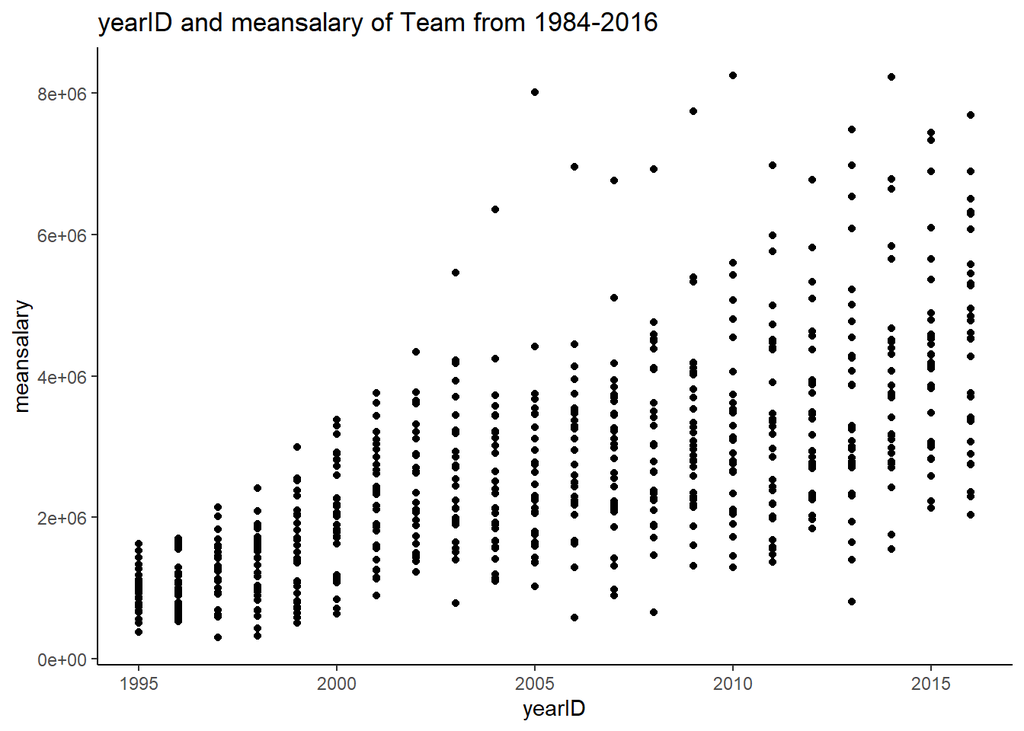

```r
Teamdata %>%
  filter(yearID >= "1984" & yearID <= "2016") %>%

  ggplot(mapping = aes(x = yearID ,y = meansalary)) +
  geom_point()+
  labs(x = "yearID", y = "meansalary") +
  ggtitle("yearID and meansalary of Team from 1984-2016") +
  theme_classic()
```

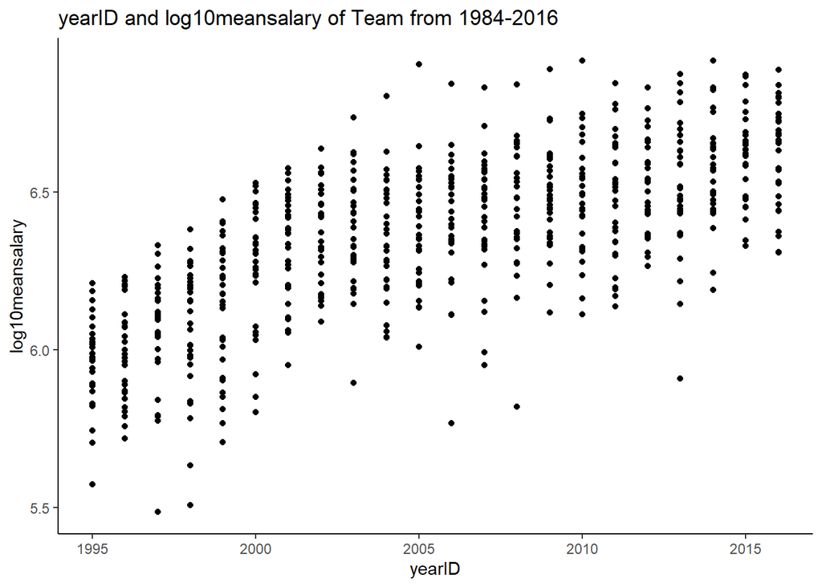

```r
logdata <- Teamdata %>%
  filter(yearID >= "1984" & yearID <= "2016") %>%
  mutate(log10meansalary = log10(meansalary))

logdata %>%
 ggplot(mapping = aes(x = yearID ,y = log10meansalary)) +
  geom_point()+
  labs(x = "yearID", y = "log10meansalary") +
  ggtitle("yearID and log10meansalary of Team from 1984-2016") +
  theme_classic()
```

A linear model is more appropriate for log because: i) In log transformation reduces or removes the skewness of raw mean salaries ii) In log transformation when yearID increases, log10meansalary increases more linear

2. [1 + 3 points] Fit a model of $log_{10}$(meansalary) as a function of yearID. Write the form of the model and explain what the Multiple R-Squared tells us.

```r
linmod1<-lm(log10meansalary ~ yearID, data = logdata)
linmod1
summary(linmod1)

linmod1$coefficients
```

```
Call:
lm(formula = log10meansalary ~ yearID, data = logdata)

Coefficients:
(Intercept)       yearID
  -51.22242      0.02871


Call:
lm(formula = log10meansalary ~ yearID, data = logdata)

Residuals:
     Min       1Q   Median       3Q      Max
-0.66345 -0.11692  0.00644  0.13394  0.55976

Coefficients:
              Estimate Std. Error t value Pr(>|t|)
(Intercept) -51.222416   2.310867  -22.17   <2e-16 ***
yearID        0.028711   0.001152   24.92   <2e-16 ***
---
Signif. codes:  0 '***' 0.001 '**' 0.01 '*' 0.05 '.' 0.1 ' ' 1

Residual standard error: 0.1858 on 652 degrees of freedom
Multiple R-squared:  0.4878,    Adjusted R-squared:  0.487
F-statistic: 620.9 on 1 and 652 DF,  p-value: < 2.2e-16

 (Intercept)       yearID
-51.22241645   0.02871141
```

$log_{10}(meansalary) \sim Ν(-51.222416 + 0.028711 \times yearID, 0.1858)$